# Lab 6: Testing and RNA-Seq

## Goal

In this lab, we will become familiar with count data in RNA-Seq high-throughput sequencing. We will see how we can use how to use DEseq2 R package for hypothesis testing to data from RNA-Seq experiments. We will model counts data and evaluate model fits to detect and quantify systematic changes between conditions, compared to within-condition variability (which we consider noise).

## Load Packages

Install packages.

```r
pkgs_needed = c("dplyr","ggplot2", "DESeq2","pasilla","genefilter",
                "pheatmap","readr","tibble","apeglm")
BiocManager::install(pkgs_needed, dependencies = TRUE)
```

Load packages.

```r
library("dplyr")
library("ggplot2")
library("DESeq2")
library("pasilla")
library("genefilter")
library("pheatmap")
library("tibble")
```

# DESeq2: Statistical Testing for Differential Expression

DESeq2 is an R package to analyze count data, such as bulk RNA-Seq. It works with a particular type of object called DESeqDataSet that contains many variables. In order to create such a DESeqDataSet, we have to convert the count and meta data according to specific requirements by the DESeq2 package. You can read about these requirements in detail in the [DESeq2 vignette](https://bioconductor.org/packages/devel/bioc/vignettes/DESeq2/inst/doc/DESeq2.html).

## Example dataset: the pasilla data

The `pasilla` data are from an experiment on Drosophila melanogaster cell cultures that investigated the **effect of RNAi knock-down of the splicing factor on the cells’ transcriptome**. The dataset is a collection of RNA-seq counts of different genes in different experimental conditions, **treated** (siRNA against pasilla) or **untreated** (negative control).  
The experimental metadata of the samples in this dataset are provided in a spreadsheet-like table. Here, we use the function `system.file` to locate a file that is shipped together with the `pasilla` package.  
When you work with your own data, simply prepare and load the corresponding file.  
Let us load an example dataset. It resides in the experiment data package `pasilla`.

```r
# this point to a file name in your computer
fn = system.file("extdata", "pasilla_gene_counts.tsv",
                  package = "pasilla", mustWork = TRUE)
# "gene_id" is the first column in the file, we can use it to define the rownames directly
counts = as.matrix(read.csv(fn, sep = "\t", row.names = "gene_id"))
```

The data are stored as a rectangular table in a tab-delimited file, which we’ve read into the matrix `counts`.

Let’s take a look at it: When loading data from a file, a good plausibility check is to print out some of the data, and maybe not only at the very beginning, but also at some random point in the middle, as we have done above. The table is a matrix of integer values: the value in the $i$th row and the $j$th column of the matrix indicates **how many reads have been mapped to gene $i$ in sample $j$**.

**Question 1**: print a point in the middle of the dataset, what are the columns in the matrix? What do they correspond to?

**Question 2**: how many genes are there in total?

**Question 3**: what is the read count for the 41st gene in the 3rd sample?

**Question 4**: what is the name of the gene? And of the sample?

```r
#TODO only in solutions
# 1.
counts[ 2000+(0:3), ]
```

```
##             untreated1 untreated2 untreated3 untreated4 treated1 treated2
## FBgn0020369       3387       4295       1315       1853     4884     2133
## FBgn0020370       3186       4305       1824       2094     3525     1973
## FBgn0020371          1          0          1          1        1        0
## FBgn0020372         38         84         29         28       63       28
##             treated3
## FBgn0020369     2165
## FBgn0020370     2120
## FBgn0020371        0
## FBgn0020372       27
```

```r
# there are 4 untreated and 3 treated samples
# 2.
nrow(counts)
```

```
## [1] 14599
```

```r
# equivalent to do
dim(counts)[1]
```

```
## [1] 14599
```

```r
# 3.
counts[41,3]
```

```
## [1] 17596
```

```r
# 4.
rownames(counts)[41] # gene name
```

```
## [1] "FBgn0000100"
```

```r
# "FBgn0000100"
colnames(counts)[3] # sample name
```

```
## [1] "untreated3"
```

```r
# "untreated3"
```

Now let’s get the annotation file, that is again part of the `pasilla` package:

```r
annotationFile = system.file("extdata", "pasilla_sample_annotation.csv",
                             package = "pasilla", mustWork = TRUE)
pasillaSampleAnno = read.csv(annotationFile)
pasillaSampleAnno
```

```
##           file condition        type number.of.lanes total.number.of.reads
## 1   treated1fb   treated single-read               5              35158667
## 2   treated2fb   treated  paired-end               2         12242535 (x2)
## 3   treated3fb   treated  paired-end               2         12443664 (x2)
## 4 untreated1fb untreated single-read               2              17812866
## 5 untreated2fb untreated single-read               6              34284521
## 6 untreated3fb untreated  paired-end               2         10542625 (x2)
## 7 untreated4fb untreated  paired-end               2         12214974 (x2)
##   exon.counts
## 1    15679615
## 2    15620018
## 3    12733865
## 4    14924838
## 5    20764558
## 6    10283129
## 7    11653031
```

As we see here, the overall dataset was produced in batches (indicated in the column `type` here) the first one consisting of sequencing libraries that were subjected to **single-read** sequencing, the second batch consisting of libraries for which **paired-end** sequencing was used.

To have a general overview of our dataset, we can use the `str()` function (you can use it with any object type)

```r
str(pasillaSampleAnno)
```

```
## 'data.frame':    7 obs. of  6 variables:
##  $ file                 : chr  "treated1fb" "treated2fb" "treated3fb" "untreated1fb" ...
##  $ condition            : chr  "treated" "treated" "treated" "untreated" ...
##  $ type                 : chr  "single-read" "paired-end" "paired-end" "single-read" ...
##  $ number.of.lanes      : int  5 2 2 2 6 2 2
##  $ total.number.of.reads: chr  "35158667" "12242535 (x2)" "12443664 (x2)" "17812866" ...
##  $ exon.counts          : int  15679615 15620018 12733865 14924838 20764558 10283129 11653031
```

Let’s convert the relevant columns of `pasillaSampleAnno` into factors, overriding the default level ordering (which is alphabetical) by one that makes more sense to us. This is needed to avoid warning messages when constructing the DEseq2 object.

```r
pasillaSampleAnno = mutate(
  pasillaSampleAnno,
  condition = factor(condition, levels = c("untreated", "treated")),
  type      = factor(type, levels = c("single-read", "paired-end")))
```

**Question 5**: Are the “condition” and “type” column still characters?

```r
# no they are factor now
str(pasillaSampleAnno)
```

```
## 'data.frame':    7 obs. of  6 variables:
##  $ file                 : chr  "treated1fb" "treated2fb" "treated3fb" "untreated1fb" ...
##  $ condition            : Factor w/ 2 levels "untreated","treated": 2 2 2 1 1 1 1
##  $ type                 : Factor w/ 2 levels "single-read",..: 1 2 2 1 1 2 2
##  $ number.of.lanes      : int  5 2 2 2 6 2 2
##  $ total.number.of.reads: chr  "35158667" "12242535 (x2)" "12443664 (x2)" "17812866" ...
##  $ exon.counts          : int  15679615 15620018 12733865 14924838 20764558 10283129 11653031
```

Let’s check if the design is balanced between the factor of interest, `condition`, and the nuisance factor `type`.  
**Question 6**: How many sample are untreated and single-read, untreated and paired-end, treated and single-read, treated and paired-end?

```r
table(pasillaSampleAnno[,c("condition","type")])
```

```
##            type
## condition   single-read paired-end
##   untreated           2          2
##   treated             1          2
```

Now that we have an idea of how the data look like, let’s prepare them for the analysis.  
We are going to use `DESeq2`. To use the functions from this package, first we need to create a `DESeqDataSet` using:

1. the `counts` matrix with read counts for each gene (gene id are in row names) in each sample (sample id are in column names)
2. the `pasillaSampleAnno` sample annotation dataframe , where per each sample we have different information.

We can use the constructor function `DESeqDataSetFromMatrix`.  
The very first step is to make sure the sample id are the same, and in the same order, in the matrix `counts` and the sample annotation dataframe `pasillaSampleAnno`.

**Hands-on:** take a look at the samples id in the two dataset, make them matching. Check that they are in the exact same order, that’s critical for running DESeq2.

```r
# sample id in `pasillaSampleAnno` are found in the column `pasillaSampleAnno$file`
# to make sure they match to sample id in `counts`,
# we need to remove the `fb` that happens to be used in the `file` column for some reason;
# and we match them with the match function to the column names of the matrix `counts`
rownames(pasillaSampleAnno) = sub("fb$", "", pasillaSampleAnno$file)
mt = match(colnames(counts), rownames(pasillaSampleAnno))
pasillaSampleAnno = pasillaSampleAnno[mt,]

# Check if the order is the same, that's critical for running DESeq2
all(rownames(pasillaSampleAnno) == colnames(counts))
```

```
## [1] TRUE
```

Now, we can move on to construct the DeSeqDataSet object. For this we will use the `DESeqDataSetFromMatrix()` function. In this function we specify the countData, the colData and the design. Here, the design argument is classifying the samples into the two groups that we want to test (treated vs untreated).

```r
pasilla = DESeqDataSetFromMatrix(
  countData = counts,
  colData   = pasillaSampleAnno,
  design    = ~ condition)

class(pasilla)
```

```
## [1] "DESeqDataSet"
## attr(,"package")
## [1] "DESeq2"
```

```r
is(pasilla, "SummarizedExperiment")
```

```
## [1] TRUE
```

**Question 7**: what is the class of `pasilla` object? Is it a “SummarizedExperiment”?  
**Answer 7**: it is a “DESeqDataSet”, specific of the “DESeq2” dataset. Yes it is.

You can always use `is()` function to check that your object is what you expect it to be.

The `SummarizedExperiment` class –and therefore `DESeqDataSet`– also contains facilities for storing annotation of the rows of the count matrix. For now, we are content with the gene identifiers from the row names of the `counts` table.

**Question 8**: When we constructed our `SummarizedExperiment` object, we also saved some column metadata which we had initially stored in `pasillaSampleAnno`. With which function can we extract this information again? (Hint: type `?SummarizedExperiment`, look at the example at the end of the help. You can also print `pasilla` and see how it looks like)

```r
colData(pasilla)
```

```
## DataFrame with 7 rows and 6 columns
##                    file condition        type number.of.lanes
##             <character>  <factor>    <factor>       <integer>
## untreated1 untreated1fb untreated single-read               2
## untreated2 untreated2fb untreated single-read               6
## untreated3 untreated3fb untreated paired-end                2
## untreated4 untreated4fb untreated paired-end                2
## treated1     treated1fb treated   single-read               5
## treated2     treated2fb treated   paired-end                2
## treated3     treated3fb treated   paired-end                2
##            total.number.of.reads exon.counts
##                      <character>   <integer>
## untreated1              17812866    14924838
## untreated2              34284521    20764558
## untreated3         10542625 (x2)    10283129
## untreated4         12214974 (x2)    11653031
## treated1                35158667    15679615
## treated2           12242535 (x2)    15620018
## treated3           12443664 (x2)    12733865
```

## The DESeq2 method

After these preparations, we are now ready to jump straight into differential expression analysis. A choice of standard analysis steps are wrapped into a single function, `DESeq`. This function takes the DESeqDataSet and returns a DESeqDataSet, but with lots of added information (normalization, dispersion estimates, differential expression results, and more). It is a “wrapper” function that calls other functions: in order, `estimateSizeFactors`, `estimateDispersions` (for dispersion estimation) and `nbinomWaldTest` (for hypothesis tests for differential abundance). (You can always call these functions individually if you want to modify their behavior or interject custom steps.) Let us look at the results.

```r
pasilla = DESeq(pasilla)
#res = results(pasilla)
res = results(pasilla, tidy = TRUE) %>% as_tibble()
res[order(res$padj), ] %>% head
```

```
## # A tibble: 6 × 7
##   row         baseMean log2FoldChange  lfcSE  stat    pvalue      padj
##   <chr>          <dbl>          <dbl>  <dbl> <dbl>     <dbl>     <dbl>
## 1 FBgn0039155     731.          -4.62 0.169  -27.4 4.89e-165 4.07e-161
## 2 FBgn0025111    1501.           2.90 0.127   22.8 1.53e-115 6.38e-112
## 3 FBgn0029167    3706.          -2.20 0.0970 -22.7 1.33e-113 3.69e-110
## 4 FBgn0003360    4343.          -3.18 0.144  -22.2 9.56e-109 1.99e-105
## 5 FBgn0035085     638.          -2.56 0.137  -18.6 1.29e- 77 2.14e- 74
## 6 FBgn0039827     262.          -4.16 0.233  -17.9 1.26e- 71 1.74e- 68
```

Finally, its time to look at the results!

### Histogram of p-values

**Question 9**: Check what kind of information is stored in the results table. Do you know why we have a p-value and an adjusted p-value? Which one should you use for further analysis of the differentially expressed genes (DE genes)?  
**Answer 9**: For our downstream analysis we should use the adjusted p-value. This p-value is taking into account the number of statistical tests DESeq2 is taking. If we don´t correct for multiple testing we will get many false positives just by chance. For example, if we use test 10000 genes and a standard p-value cut-off of 0.05, we would expect 500 genes to be significantly differentially expressed by chance.

One first important step is to visualize the data and to look a their distribution.

Let’s take a look at the p-value distribution:

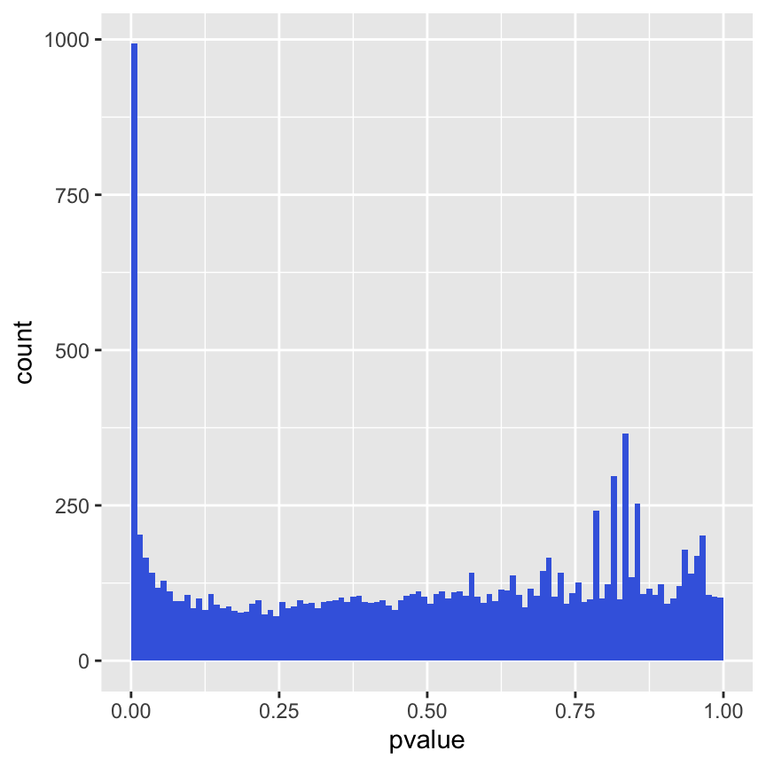

```r
ggplot(as(res, "data.frame"), aes(x = pvalue)) +
  geom_histogram(binwidth = 0.01, fill = "Royalblue", boundary = 0)
```

The distribution displays two main components: a uniform background with values between 0 and 1, and a peak of small p-values at the left.

**Question 10**: which genes do you think correspond to differentially expressed genes? Why?

**Answer 10**: The uniform background corresponds to the non-differentially expressed genes. Usually this is the majority of genes. The left hand peak corresponds to differentially bioexpressed genes.

The ratio of the level of the background to the height of the peak gives us a rough indication of the false discovery rate (FDR) that would be associated with calling the genes in the leftmost bin differentially expressed.

There are different methods for the FDR p-value correction, internally DESeq2 uses a method that is more advanced than the widely used Benjamini-Hochberg method (a simplified variant of IHW in which low counts genes get filtered out). You can find the adjusted p-values in `res$padj`.

We can use the p-value histogram plot for diagnostic purposes. Let’s look at a simulation to understand this point. First, we simulate four samples under the null hypothesis in which we state that the mean and the variance of the two conditions are the same; the alternative hypothesis state that mean and variance in the two conditions are different - the genes are differentially expressed.  
Then we apply the t-tests:

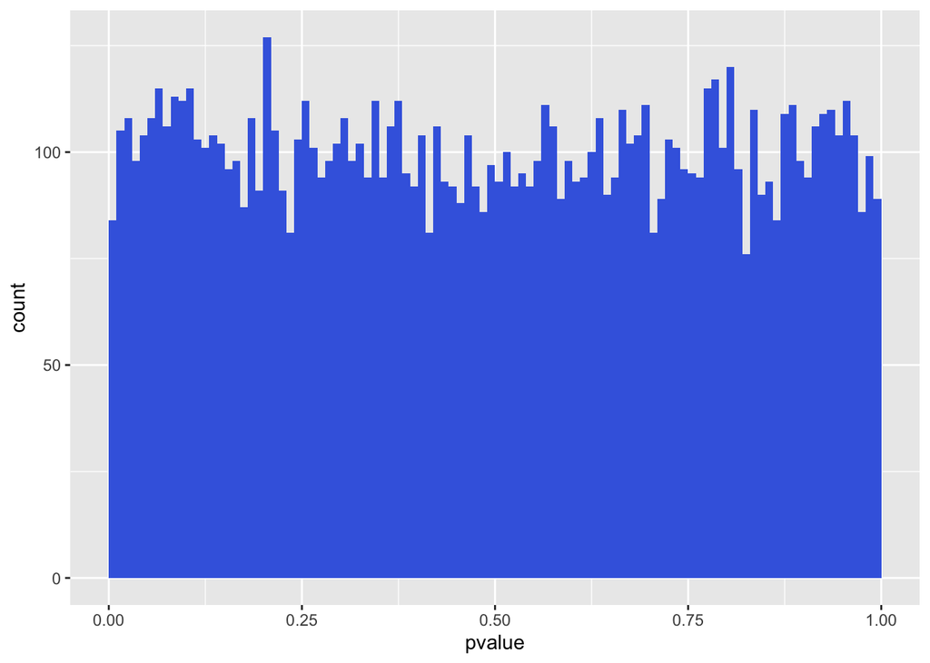

```r
set.seed(0xdada2)
# rnorm is a function that simulates a normal distribution,
# sampling 10000 numbers, from a distribution of mean 0 and variance 0
# All 4 samples (2 Controls and 2 Treated) have the same mean
y = cbind(rnorm(10000, 0, 1),
          rnorm(10000, 0, 1),
          rnorm(10000, 0, 1),
          rnorm(10000, 0, 1))
library(genefilter)
pvalue = rowttests(y, factor(c("C","C","T","T")))$p.value
ggplot(tibble(pvalue), aes(x = pvalue)) +
  geom_histogram(binwidth = 0.01, fill = "Royalblue", boundary = 0)
```

Looks good. All pvalues are background because there is not difference between control and treatment.

**Question 11**: Now try to modify the code above:

1. by simulating two control samples with mean different from the two treated samples, how does the plot look like?

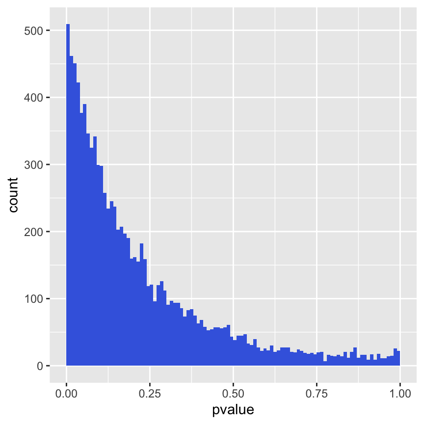

```r
#a. by simulating two control samples with mean different from the two treated samples, how does the plot look like?
# when we run random numbers, we can set a seed so that R will start always from the same random series, in this way the result is reproducible
# if we want to change the result, we can change the seed
set.seed(0xdada2)
y = cbind(rnorm(10000, 0, 1),
          rnorm(10000, 0, 1),
          rnorm(10000, 2, 1),
          rnorm(10000, 2, 1))
pvalue = rowttests(y, factor(c("C","C","T","T")))$p.value
ggplot(tibble(pvalue), aes(x = pvalue)) +
  geom_histogram(binwidth = 0.01, fill = "Royalblue", boundary = 0)
```

Now let’s assume that two samples were processed on the same day separately from the others. That day, something happened and the means in both samples were shifted. In that case, the histogram is skewed to the right.

**Question 12**: Again, try to modify the code above to simulate this:  
b. Imagine that sample 2 and sample 4 were processed on the same day and for some reason their mean are shifted to the right. Can you simulate this? What do you observe?

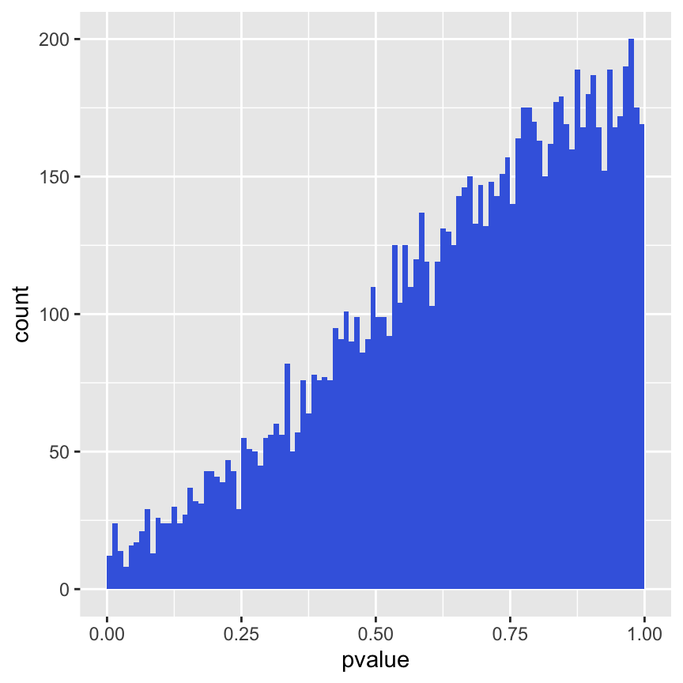

```r
#b. Imagine that sample 2 and sample 4 were processed on the same day and for some reason their mean are shifted to the right:
set.seed(0xdada2)
y = cbind(rnorm(10000, 0, 1),
          rnorm(10000, 2, 1),
          rnorm(10000, 0, 1),
          rnorm(10000, 2, 1))
pvalue = rowttests(y, factor(c("C","C","T","T")))$p.value
ggplot(tibble(pvalue), aes(x = pvalue)) +
  geom_histogram(binwidth = 0.01, fill = "Royalblue", boundary = 0)
```

One way to take such batch effects into account is by adding the batch factor (e.g. the run day) in our model.

What can you do if you suspect there are ‘’hidden’’ factors that affect your data, but they are not documented? (Sometimes, such unknown/undocumented covariates are also called batch effects.) There are methods that try to identify blocking factors in an unsupervised fashion, see e.,g., [Leek and Storey 2007](http://journals.plos.org/plosgenetics/article?id=10.1371/journal.pgen.0030161) or [Stegle et al 2010](http://journals.plos.org/ploscompbiol/article?id=10.1371/journal.pcbi.1000770).

Now that we have checked that they distribute as expected, we can look at our results:

**Hands-on:**

1. How many genes are differentially expressed, if we set the significance threshold for the adjusted p-value to < 0.05?
2. Select one of the top DE genes of your analysis (genes with the lowest adjusted p-values). For this gene, obtain the count table using DESeqs `plotCounts()` function and plot the counts across the condition (treated vs. untreated) for this gene. Tip: You can either use this function directly for plotting, or you can set `returnData=TRUE` to obtain a count table and use this count table as input for ggplot.
3. Most of the time, we are not interested in one single DE gene but we want to get an overview of all of them. Look up the Wikipedia article on volcano plots. Using the results table, make a volcano plot that shows the log2 fold change on the x-axis, and the -log10 of the p-value on the y-axis. Color-code by whether the gene is significant and give your plot a title.

```r
# How many genes are differentially expressed (padj < 0.05)?
res %>% filter(padj < 0.05) %>% nrow()
```

```
## [1] 845
```

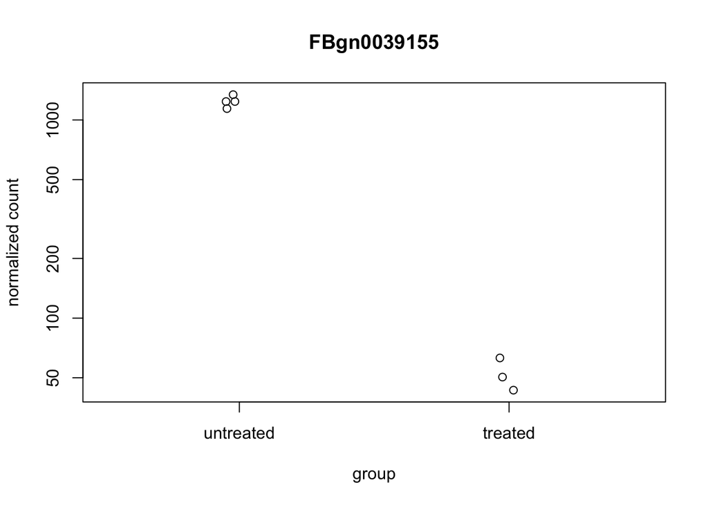

```r
# Plot one of the counts across the two groups of one of the top DE genes?

# First we order the DE genes according to their p-value
DE_genes_ordered <- res %>% filter(padj < 0.05) %>%
  arrange(padj)

# Let´s plot the first one from the list
# by changing this you can easily rerun the code below to plot the results for another gene
gene_oi = "FBgn0039155"

# Plot it with the DESeq2 function
plotCounts(pasilla, gene=gene_oi)
```

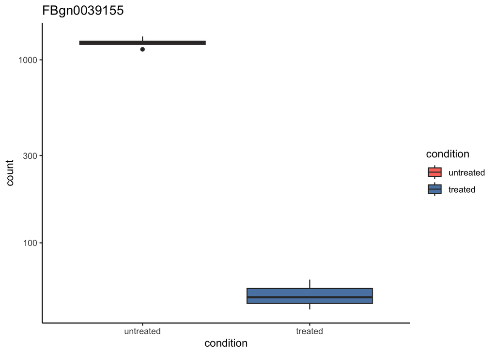

```r
# Plot it with ggplot
plotCounts(pasilla, gene=gene_oi, returnData=TRUE) %>%
  ggplot(aes(condition, count)) +
  geom_boxplot(aes(fill=condition)) +
  scale_y_log10() +
  theme_classic() +
  scale_fill_manual(values = c("#FC766AFF", "#5B84B1FF")) +
  ggtitle(gene_oi)
```

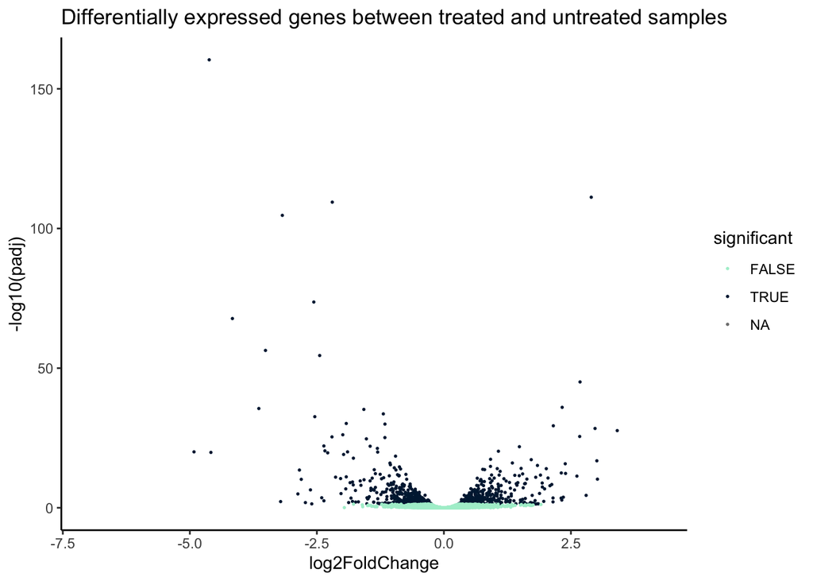

```r
# Make a Volcano Plot
vol_to_plot <- res %>%
  mutate(significant = ifelse(padj < 0.05, TRUE, FALSE)) %>%
  arrange(padj)

ggplot(vol_to_plot, aes(x = log2FoldChange, y = -log10(padj), color = significant)) +
  geom_point(size = 0.3) +
  theme_classic() +
  scale_color_manual(values = c("#ADEFD1FF", "#00203FFF")) +
  ggtitle("Differentially expressed genes between treated and untreated samples")
```

Amazing! You performed your first Differential Expression Analysis!

## Advanced DESeq2: Two-factor analysis of the pasilla data

**Covariates** can complicate our analysis and that it´s very important to account for them.

Besides the treatment with siRNA, the `pasilla` data have another covariate, `type`, which indicates the type of sequencing that was performed.

One way to test whether a covariate is influencing our analysis can be by looking at the Principal Component Analysis:

### PCA plot

This type of plot is useful for visualizing the overall effect of experimental covariates and/or to detect batch effects. First we need a data transformation, the regularized logarithm or `rlog`.

**Question 13**: Can you reproduce the PCA plot below using `plotPCA`? Don’t forget to transform the data (tip: there’s a function for that too `?rlogTransformation`)

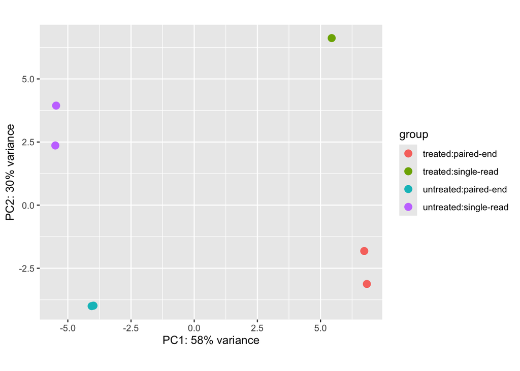

**Question 14**: take a look at the plot, how do the sample distribute? Which component are important to explain this distribution?  
**Answer 14**: Here, the first principal axis, PC1, is mostly aligned with the experimental covariate of interest (untreated / treated), while the second axis is roughly aligned with the sequencing protocol (single-read / paired-end).

With a PCA we can see that the sequencing `type` has a considerable systematic effect on the data. Our basic analysis did not take this account, but we will do so now. This should help us get a more correct picture of which differences in the data are attributable to the treatment, and which are confounded –or masked– by the sequencing type.

**Hands-on:**  
Rerun the differential expression analysis, but this time account for `type` using a multi-factor design. For this, go to the [DESeq2 vignette](https://bioconductor.org/packages/devel/bioc/vignettes/DESeq2/inst/doc/DESeq2.html#multi-factor-designs) and read about how to use multi-factor designs.

```r
pasillaTwoFactor = pasilla

# usign the 'design' function we can change the formula and include the covariates
design(pasillaTwoFactor) = formula(~ type + condition)
```

```
##   Note: levels of factors in the design contain characters other than
##   letters, numbers, '_' and '.'. It is recommended (but not required) to use
##   only letters, numbers, and delimiters '_' or '.', as these are safe characters
##   for column names in R. [This is a message, not a warning or an error]
```

```r
# Or we can create a new one using DESeqDataSetFromMatrix again, where we put change the design argument - this is equivalent to the one above
pasillaTwoFactor <- DESeqDataSetFromMatrix(countData = counts,
                              colData = pasillaSampleAnno,
                              design = ~ type + condition)
```

```
##   Note: levels of factors in the design contain characters other than
##   letters, numbers, '_' and '.'. It is recommended (but not required) to use
##   only letters, numbers, and delimiters '_' or '.', as these are safe characters
##   for column names in R. [This is a message, not a warning or an error]
```

```r
# Note: Of the two variables `type` and `condition`, the one of primary interest
# is the `condition`, and in `DESeq2`, the convention is to put it at the end of the
# formula. This convention has no effect on the model fitting, but it helps
# simplify some of the subsequent results reporting.

#Rerun the DESeq() function
pasillaTwoFactor <- DESeq(pasillaTwoFactor)
```

```
##   Note: levels of factors in the design contain characters other than
##   letters, numbers, '_' and '.'. It is recommended (but not required) to use
##   only letters, numbers, and delimiters '_' or '.', as these are safe characters
##   for column names in R. [This is a message, not a warning or an error]
```

```
##   Note: levels of factors in the design contain characters other than
##   letters, numbers, '_' and '.'. It is recommended (but not required) to use
##   only letters, numbers, and delimiters '_' or '.', as these are safe characters
##   for column names in R. [This is a message, not a warning or an error]
```

```r
#Storing the results table
res2 = results(pasillaTwoFactor)
head(res2, n = 3)
```

```
## log2 fold change (MLE): condition treated vs untreated
## Wald test p-value: condition treated vs untreated
## DataFrame with 3 rows and 6 columns
##              baseMean log2FoldChange     lfcSE       stat    pvalue      padj
##             <numeric>      <numeric> <numeric>  <numeric> <numeric> <numeric>
## FBgn0000003  0.171569      0.6745518  3.871091  0.1742537  0.861666        NA
## FBgn0000008 95.144079     -0.0406731  0.222215 -0.1830351  0.854770  0.951975
## FBgn0000014  1.056572     -0.0849880  2.111821 -0.0402439  0.967899        NA
```

```r
# We can retrieve the *log_2* fold changes, p-values and adjusted p-values associated with the `type` variable.
# The function `results` takes an argument `contrast` that
# lets users specify the name of the variable, the level
# that corresponds to the numerator of the fold change and the level that corresponds
# to the denominator of the fold change.
resType = results(pasillaTwoFactor,
                  contrast = c("type", "single-read", "paired-end"), tidy = TRUE) %>% as_tibble()
head(resType, n = 3)
```

```
## # A tibble: 3 × 7
##   row         baseMean log2FoldChange lfcSE   stat pvalue   padj
##   <chr>          <dbl>          <dbl> <dbl>  <dbl>  <dbl>  <dbl>
## 1 FBgn0000003    0.172         -1.61  3.87  -0.416  0.677 NA
## 2 FBgn0000008   95.1           -0.262 0.221 -1.19   0.235  0.544
## 3 FBgn0000014    1.06           3.29  2.09   1.58   0.115 NA
```

So what did we gain from this analysis that took into account `type` as a nuisance factor (sometimes also called, more politely, a “blocking factor”), compared to the simple comparison between two groups?

**Question 15**: How many genes are significantly differentially expressed in the new results?  
**Question 16**: How big is the overlap of the DE genes, if you take the covariate sequencing type into account?

```r
# 15.How many genes are significantly differentially expressed?
resType %>% filter(padj < 0.05) %>% nrow()
```

```
## [1] 902
```

```r
# 16.How big is the overlap of the DE genes, if you take the covariate sex into account?
DE_genes_cov <- resType %>% filter(padj < 0.05) %>%
  arrange(padj)

length(intersect(DE_genes_ordered$row, DE_genes_cov$row))
```

```
## [1] 66
```

Let us plot the p-values from both analyses against each other.

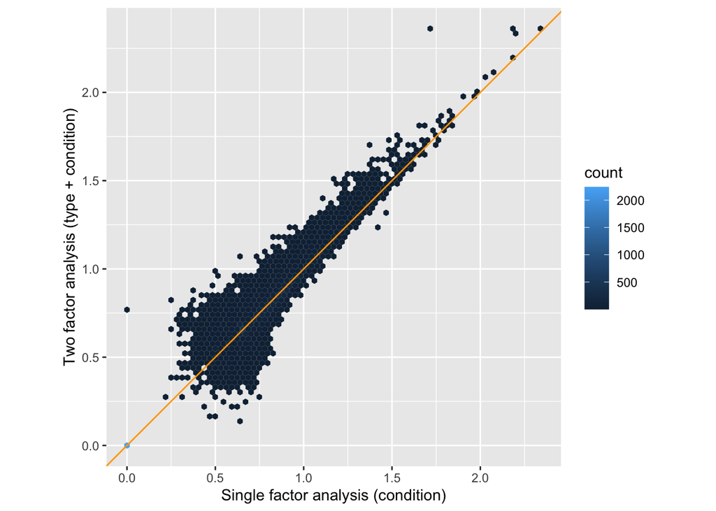

```r
trsf = function(x) ifelse(is.na(x), 0, (-log10(x)) ^ (1/6))
ggplot(tibble(pOne = res$pvalue,
              pTwo = res2$pvalue),
    aes(x = trsf(pOne), y = trsf(pTwo))) +
    geom_hex(bins = 75) + coord_fixed() +
    xlab("Single factor analysis (condition)") +
    ylab("Two factor analysis (type + condition)") +
    geom_abline(col = "orange")
```

Comparison of p-values from the models with a single factor (condition) and with two factors (type + condition). The axes correspond to $(-\log_{10}p)^{\frac{1}{6}}$, an arbitrarily chosen monotonically decreasing transformation that compresses the dynamic range of the p-values for the purpose of visualization. We can see a trend for the joint distribution to lie above the bisector, indicating that the p-values in the two-factor analysis are generally smaller than those in the one-factor analysis.

As we can see, the p-values in the **two-factor analysis** are similar to those from the one-factor analysis, but are generally smaller. The more sophisticated analysis has led to an, albeit modest, **increase in power.** We can also see this by counting the number of genes that pass a certain significance threshold in each case:

```r
compareRes = table(
   `simple analysis` = res$padj < 0.1,
   `two factor` = res2$padj < 0.1 )
addmargins( compareRes )
```

```
##                two factor
## simple analysis FALSE TRUE  Sum
##           FALSE  6973  289 7262
##           TRUE     25 1036 1061
##           Sum    6998 1325 8323
```

The two-factor analysis found 1325 genes differentially expressed at an FDR threshold of 10%, while the one-factor analysis found 1061. The two-factor analysis has increased detection power. In general, the gain can be even much larger, or also smaller, depending on the data. The proper choice of the model requires informed adaptation to the experimental design and data quality.

Why do we detect fewer significant genes when we do not take into account the `type` variable? More generally, what does this mean about the benefit of taking into account (or not) blocking factors?

Without modeling the blocking factor, the variability in the data that is due to it has to be absorbed by the $\varepsilon$s. This means that they are generally larger than in the model with the blocking factor. The higher level of noise leads to higher uncertainty in the $\beta$-estimates. On the other hand, the model with the blocking factor has more parameters that need to be estimated. In statistical parlance, the fit has fewer ``degrees of freedom’’.  
Both of these effects are counteracting, and which of them prevails, and which of the modeling choices yields more or fewer significant results depends on the data.

As a note of caution: The two p-values calculated above (one with ~condition and one with ~type+condition) correspond to different null hypotheses. This can be a problem when the blocking factor and condition are correlated.